# 20250410_slides slides

```python
%%html
<iframe width="560" height="315" src="https://www.youtube.com/embed/Opxhh9Oh3rg?si=KY4Rj5W1MYjhstSv&autoplay=1;&amp;controls=1" title="YouTube video player" frameborder="0" allow="accelerometer; clipboard-write; encrypted-media; gyroscope; picture-in-picture; web-share" allowfullscreen></iframe>
# manual video start
```

[video not shown]

# manual video start

```python
# %%html
# <iframe width="560" height="315" src="https://www.youtube.com/embed/Opxhh9Oh3rg?si=KY4Rj5W1MYjhstSv&autoplay=1;&amp;controls=1" title="YouTube video player" frameborder="0" allow="accelerometer; autoplay; clipboard-write; encrypted-media; gyroscope; picture-in-picture; web-share" allowfullscreen></iframe>
# auto-play video start
```

## Data Science With The Beatles: Statistically the Best Pop Act Ever?

## In November of 2023, the legendary rock band The Beatles released the No. 1 hit song "Now and Then" and topped the Billboard charts in the U.K. The world experienced Beatlemania again for the first time in over a half-century. And if that wasn't enough awesomeness, they followed that up in February of 2025 by winning the Grammy Award for Best Rock Performance with it as the first song assisted by Artificial Intelligence technology to win a Grammy in history. Still continuing to blaze trails as rock poineers up until their very last song recorded with all four of The Beatles; John, Paul, George, & Ringo. AND it was produced by Giles Martin, talented son of the genius Sir George Martin (R.I.P.) Mind blown.

## How many bands can say they've done that?!? First of all; NONE. Secondly, especially not with half of the members on the track having passed away by the time it was released (R.I.P. John & George!)

## Might it be possible to gain some insight on their hit-making formula using data science?

## This notebook details the journey for that answer...

## High-Level Method: Exploratory Data Analysis (EDA)

### First, inspect the input data. Make sure the file isn't corrupted or garbage.

## High-level Mechanics: Import data into dataframe and review

```python
import pandas as pd
df = pd.read_csv('hot-100-current.csv') #Billboard top 100 chart from November 2023
df.head()
```

|  | chart_week | current_week | title | performer | last_week | peak_pos | wks_on_chart |
| --- | --- | --- | --- | --- | --- | --- | --- |
| 0 | 2022-01-01 | 1 | All I Want For Christmas Is You | Mariah Carey | 1.0 | 1 | 50 |
| 1 | 2022-01-01 | 2 | Rockin' Around The Christmas Tree | Brenda Lee | 2.0 | 2 | 44 |
| 2 | 2022-01-01 | 3 | Jingle Bell Rock | Bobby Helms | 4.0 | 3 | 41 |
| 3 | 2022-01-01 | 4 | A Holly Jolly Christmas | Burl Ives | 5.0 | 4 | 25 |
| 4 | 2022-01-01 | 5 | Easy On Me | Adele | 3.0 | 1 | 11 |

### Nope, it's not garbage.

## Method: Next get the basic dataframe stats info to dig deeper into the data.

## Mechanics: describe()

```python
df.describe()
```

|  | current_week | last_week | peak_pos | wks_on_chart |
| --- | --- | --- | --- | --- |
| count | 341500.000000 | 309040.000000 | 341500.000000 | 341500.000000 |
| mean | 50.500000 | 47.288807 | 40.682214 | 9.291154 |
| std | 28.866032 | 28.179708 | 29.332586 | 7.866871 |
| min | 1.000000 | 0.000000 | 1.000000 | 1.000000 |
| 25% | 26.000000 | 23.000000 | 13.000000 | 4.000000 |
| 50% | 51.000000 | 47.000000 | 38.000000 | 7.000000 |
| 75% | 75.000000 | 71.000000 | 65.000000 | 13.000000 |
| max | 100.000000 | 100.000000 | 100.000000 | 91.000000 |

### Eyeball for anomolies in the stats. Any missing data relative to the rest of the dataset? Count row: "last_week" column = 309040 records with legit values - significantly less than other three numerical columns at 341500. Investigate possible issues: any nulls (aka NaNs in Python) in any records?

```python
# From above, amount of records suspected to have NaNs or nulls in them
341500-309040
```

```
32460
```

### Find the NaNs.

```python
df[df['last_week'].isnull()]
# Yes!! that's it! I got 32640 rows
```

|  | chart_week | current_week | title | performer | last_week | peak_pos | wks_on_chart |
| --- | --- | --- | --- | --- | --- | --- | --- |
| 10700 | 1958-08-04 | 1 | Poor Little Fool | Ricky Nelson | NaN | 1 | 1 |
| 10701 | 1958-08-04 | 2 | Patricia | Perez Prado And His Orchestra | NaN | 2 | 1 |
| 10702 | 1958-08-04 | 3 | Splish Splash | Bobby Darin | NaN | 3 | 1 |
| 10703 | 1958-08-04 | 4 | Hard Headed Woman | Elvis Presley With The Jordanaires | NaN | 4 | 1 |
| 10704 | 1958-08-04 | 5 | When | Kalin Twins | NaN | 5 | 1 |
| ... | ... | ... | ... | ... | ... | ... | ... |
| 341441 | 2021-11-13 | 42 | Somebody's Watching Me | Rockwell | NaN | 2 | 20 |
| 341460 | 2021-11-13 | 61 | Demon High | Lil Uzi Vert | NaN | 61 | 1 |
| 341480 | 2021-11-13 | 81 | Rap Freaks | Yung Miami | NaN | 81 | 1 |
| 341481 | 2021-11-13 | 82 | Eat It | Megan Thee Stallion | NaN | 82 | 1 |
| 341499 | 2021-11-13 | 100 | Ghost Town | Benson Boone | NaN | 100 | 1 |

32460 rows × 7 columns

```python
df[df['performer']=='Rockwell']
```

|  | chart_week | current_week | title | performer | last_week | peak_pos | wks_on_chart |
| --- | --- | --- | --- | --- | --- | --- | --- |
| 142272 | 1984-01-28 | 73 | Somebody's Watching Me | Rockwell | NaN | 73 | 1 |
| 142351 | 1984-02-04 | 52 | Somebody's Watching Me | Rockwell | 73.0 | 52 | 2 |
| 142432 | 1984-02-11 | 33 | Somebody's Watching Me | Rockwell | 52.0 | 33 | 3 |
| 142525 | 1984-02-18 | 26 | Somebody's Watching Me | Rockwell | 33.0 | 26 | 4 |
| 142611 | 1984-02-25 | 12 | Somebody's Watching Me | Rockwell | 26.0 | 12 | 5 |
| 142706 | 1984-03-03 | 7 | Somebody's Watching Me | Rockwell | 12.0 | 7 | 6 |
| 142804 | 1984-03-10 | 5 | Somebody's Watching Me | Rockwell | 7.0 | 5 | 7 |
| 142902 | 1984-03-17 | 3 | Somebody's Watching Me | Rockwell | 5.0 | 3 | 8 |
| 143001 | 1984-03-24 | 2 | Somebody's Watching Me | Rockwell | 3.0 | 2 | 9 |
| 143101 | 1984-03-31 | 2 | Somebody's Watching Me | Rockwell | 2.0 | 2 | 10 |
| 143201 | 1984-04-07 | 2 | Somebody's Watching Me | Rockwell | 2.0 | 2 | 11 |
| 143302 | 1984-04-14 | 3 | Somebody's Watching Me | Rockwell | 2.0 | 2 | 12 |
| 143406 | 1984-04-21 | 7 | Somebody's Watching Me | Rockwell | 3.0 | 2 | 13 |
| 143510 | 1984-04-28 | 11 | Somebody's Watching Me | Rockwell | 7.0 | 2 | 14 |
| 143623 | 1984-05-05 | 24 | Somebody's Watching Me | Rockwell | 11.0 | 2 | 15 |
| 143678 | 1984-05-05 | 79 | Obscene Phone Caller | Rockwell | NaN | 79 | 1 |
| 143736 | 1984-05-12 | 37 | Somebody's Watching Me | Rockwell | 24.0 | 2 | 16 |
| 143767 | 1984-05-12 | 68 | Obscene Phone Caller | Rockwell | 79.0 | 68 | 2 |
| 143851 | 1984-05-19 | 52 | Somebody's Watching Me | Rockwell | 37.0 | 2 | 17 |
| 143860 | 1984-05-19 | 61 | Obscene Phone Caller | Rockwell | 68.0 | 61 | 3 |
| 143956 | 1984-05-26 | 57 | Obscene Phone Caller | Rockwell | 61.0 | 57 | 4 |
| 143964 | 1984-05-26 | 65 | Somebody's Watching Me | Rockwell | 52.0 | 2 | 18 |
| 144051 | 1984-06-02 | 52 | Obscene Phone Caller | Rockwell | 57.0 | 52 | 5 |
| 144088 | 1984-06-02 | 89 | Somebody's Watching Me | Rockwell | 65.0 | 2 | 19 |
| 144142 | 1984-06-09 | 43 | Obscene Phone Caller | Rockwell | 52.0 | 43 | 6 |
| 144240 | 1984-06-16 | 41 | Obscene Phone Caller | Rockwell | 43.0 | 41 | 7 |
| 144338 | 1984-06-23 | 39 | Obscene Phone Caller | Rockwell | 41.0 | 39 | 8 |
| 144434 | 1984-06-30 | 35 | Obscene Phone Caller | Rockwell | 39.0 | 35 | 9 |
| 144548 | 1984-07-07 | 49 | Obscene Phone Caller | Rockwell | 35.0 | 35 | 10 |
| 144656 | 1984-07-14 | 57 | Obscene Phone Caller | Rockwell | 49.0 | 35 | 11 |
| 144769 | 1984-07-21 | 70 | Obscene Phone Caller | Rockwell | 57.0 | 35 | 12 |
| 144872 | 1984-07-28 | 73 | Obscene Phone Caller | Rockwell | 70.0 | 35 | 13 |
| 144983 | 1984-08-04 | 84 | Obscene Phone Caller | Rockwell | 73.0 | 35 | 14 |
| 341441 | 2021-11-13 | 42 | Somebody's Watching Me | Rockwell | NaN | 2 | 20 |

```python
df['song_woc_max'] = df.groupby(['performer', 'title'], as_index=False)['wks_on_chart'].transform('max')
df['song_peak_min'] = df.groupby(['performer', 'title'], as_index=False)['peak_pos'].transform('min')
df.head()
# Note the song Let's Go Brandon appears under two different performers,
# which shows why I had to group by performer AND title
```

|  | chart_week | current_week | title | performer | last_week | peak_pos | wks_on_chart | song_woc_max | song_peak_min |
| --- | --- | --- | --- | --- | --- | --- | --- | --- | --- |
| 0 | 2022-01-01 | 1 | All I Want For Christmas Is You | Mariah Carey | 1.0 | 1 | 50 | 65 | 1 |
| 1 | 2022-01-01 | 2 | Rockin' Around The Christmas Tree | Brenda Lee | 2.0 | 2 | 44 | 58 | 1 |
| 2 | 2022-01-01 | 3 | Jingle Bell Rock | Bobby Helms | 4.0 | 3 | 41 | 56 | 3 |
| 3 | 2022-01-01 | 4 | A Holly Jolly Christmas | Burl Ives | 5.0 | 4 | 25 | 39 | 4 |
| 4 | 2022-01-01 | 5 | Easy On Me | Adele | 3.0 | 1 | 11 | 31 | 1 |

### High-level Message Note 1: I can confidentally see there isn't any significant concern because it appears the values are legitimate as they all have a value of 1 in their wks_on_chart column or they re-entered charts after falling off of it.

### Question (Motivation) #1: Has anyone had a song on the charts longer than the longest Beatles' song ever on the charts?

### Method 1: First, isolate the Beatles data in their own dataframe and all other artists in a different one to compare easily. I'll also group the ROW df by performer & title in case there are any songs that released by more than one artist (covers) and then sort both dfs by wks_on_chart in descending order.

### Two categories: The Beatles song on the charts the longest vs. the Non-Beatles song on the charts the longest.

### Mechanics 1: Create dataframes of data grouping by performer & title to determine the longest artist-song runs with max() and compare. Data visualization: also compare with bar plot.

```python
df2 = pd.read_csv('hot-100-current.csv')
max2 = df2.groupby(['performer','title'],as_index=False)['wks_on_chart'].max()
max3 = max2.sort_values(by=['wks_on_chart'], ascending=False)
max3.head()
```

|  | performer | title | wks_on_chart |
| --- | --- | --- | --- |
| 10432 | Glass Animals | Heat Waves | 91 |
| 28565 | The Weeknd | Blinding Lights | 90 |
| 11692 | Imagine Dragons | Radioactive | 87 |
| 416 | AWOLNATION | Sail | 79 |
| 7823 | Dua Lipa | Levitating | 77 |

```python
# wow so see, what's with the come together/something line? why isn't it hashed with got to get you into my life, which is also 16 weeks?
# remember to look it up online later - stay on target!
max1 = max3[max3['performer']=='The Beatles']
max1.head()
```

|  | performer | title | wks_on_chart |
| --- | --- | --- | --- |
| 25563 | The Beatles | Twist And Shout | 26 |
| 25525 | The Beatles | Hey Jude | 19 |
| 25514 | The Beatles | Come Together/Something | 16 |
| 25522 | The Beatles | Got To Get You Into My Life | 16 |
| 25551 | The Beatles | She Loves You | 15 |

### Message 1: Wow, yes! there's been a lot of songs on the charts with runs longer than the Beatles longest running song, Twist and Shout at 26 weeks. The longest being Glass Animals with Heat Waves at a wopping 91 weeks! I was not expecting that... :(

```python
# Longest running song on the charts in weeks by an artist?
allmaxweeks = max3.iloc[0].wks_on_chart
allmaxperformer = max3.iloc[0].performer
allmaxtitle = max3.iloc[0].title
# print(max3.iloc[0])

# longest running song on the charts by The Beatles
bmaxweeks = max1.iloc[0].wks_on_chart
#bmaxperformer = max1.iloc[0].performer
bmaxtitle = max1.iloc[0].title
# max1.iloc[0]
```

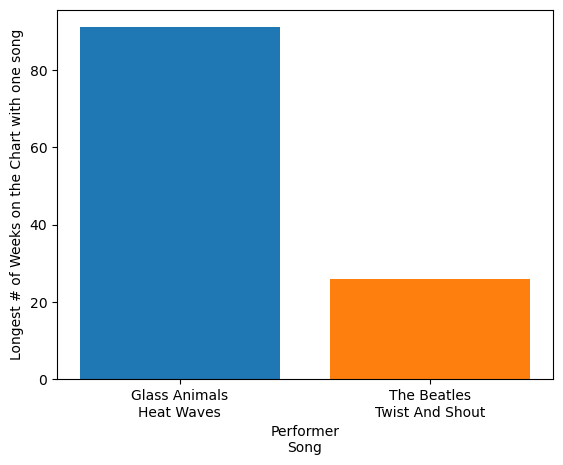

```python
import matplotlib.pyplot as plt
plt.xlabel("Performer\n"+"Song")
plt.ylabel("Longest # of Weeks on the Chart with one song")
plt.bar(allmaxperformer+"\n"+allmaxtitle, allmaxweeks)
plt.bar('The Beatles'+"\n"+bmaxtitle, bmaxweeks);
```

### Motivation 2: How many other bands have hit #1 like the Beatles? How many other songs have hit #1?

### Method 2: (EDA Part 2): First, I'm curious about how many number one songs are in the file.

### Mechanics 2: Review counts of all columns if data records of #1 hits.

```python
df2[df2['peak_pos']==1].count()
```

```
chart_week      17762
current_week    17762
title           17762
performer       17762
last_week       17671
peak_pos        17762
wks_on_chart    17762
dtype: int64
```

### Message 2: Close, but that's just a count of RECORDS that the non-NaN values in the columns where "1" is the value in the peak_pos column, but there could be many records for the same song with a peak_pos of 1. What I do find interesting is that there appear to be some songs that debuted at #1 b/c there are some songs that have a NaN (discovered above) for the last_week column. More significance to investigate later as possible Question / Problem / Motivation.

### Motivation 3: Find out how many songs that enter billboard 100 equal Beatles peak_pos #1.

### Method 3 / EDA 3: First, I'll isolate the Beatles raw data and look at the all of the numerical variables' histograms. Second, let me see the distribution of the max peak chart positions for each performer/song data record, just to see what the shape (I predict it is a long tail to the left so neg skewness since it is harder to get a #1) of distribution of peak_pos which is a histogram since it is numeric data, I can do one-hot swapping of the categoricals once I get to regression.

### Mechanics 3: Use dataframes to manipulate data and visualize into histogram distributions.

```python
df = df[df['performer'] == 'The Beatles']
df.head()
```

|  | chart_week | current_week | title | performer | last_week | peak_pos | wks_on_chart | song_woc_max | song_peak_min |
| --- | --- | --- | --- | --- | --- | --- | --- | --- | --- |
| 9806 | 2023-11-18 | 7 | Now And Then | The Beatles | 0.0 | 7 | 1 | 2 | 7 |
| 9975 | 2023-11-25 | 76 | Now And Then | The Beatles | 7.0 | 7 | 2 | 2 | 7 |
| 39144 | 1964-01-18 | 45 | I Want To Hold Your Hand | The Beatles | NaN | 45 | 1 | 15 | 1 |
| 39202 | 1964-01-25 | 3 | I Want To Hold Your Hand | The Beatles | 45.0 | 3 | 2 | 15 | 1 |
| 39268 | 1964-01-25 | 69 | She Loves You | The Beatles | NaN | 69 | 1 | 15 | 1 |

```python
max1['song_peak_min'] = df2.groupby(['performer', 'title'], as_index=False)['peak_pos'].transform('min')
max3['song_peak_min'] = df2.groupby(['performer', 'title'], as_index=False)['peak_pos'].transform('min')
# max1
```

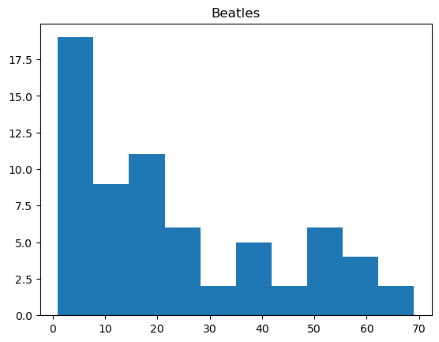

```python
plt.hist(max1['song_peak_min']);
plt.title('Beatles');
plt.show()
```

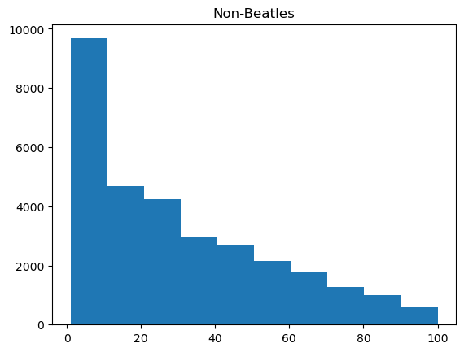

```python
plt.hist(x='song_peak_min', data=max3);
plt.title("Non-Beatles");
```

### Motivation 4: What is the average max peak_pos and average max wks_on_chart for entire file (all title/band combos)?

### Method 4: EDA & Take the means of the above columns to find out what the total song records mean is for peak_pos col

### Mechanics 4: Use dataframe function(s) describe() and set mean to var

```python
maxwks_minpeak_all.describe()
```

|  | wks_on_chart | peak_pos |
| --- | --- | --- |
| count | 31052.000000 | 31052.000000 |
| mean | 11.011883 | 46.795826 |
| std | 8.514665 | 30.461866 |
| min | 1.000000 | 1.000000 |
| 25% | 4.000000 | 19.000000 |
| 50% | 9.000000 | 46.000000 |
| 75% | 16.000000 | 73.000000 |
| max | 91.000000 | 100.000000 |

```python
# so the average peak position of a band/title combo on the charts is
min_peak_pos_mean = maxwks_minpeak_all.agg(x=('peak_pos','mean'))
```

### Message 4: Avg min peak position for all artist-song combos is 47. Almost 50 as CLT predicts.

```python
min_peak_pos_mean
```

|  | peak_pos |
| --- | --- |
| x | 46.795826 |

### Question/Motivation 4.5: What is Beatles avg. peak pos.?

### Method: take the mean of all the songs' min peak_pos

### Mechanics: group the df by title set 2 sets of vars for the means of the min peak_pos of each song, Beatles and non-Beatles

```python
max_wks_peak_beat = df.groupby(['performer', 'title'], as_index=False).agg({'wks_on_chart': 'max', 'peak_pos': 'min'})
max_wks_peak_beat_mean = max_wks_peak_beat.groupby(by='performer').agg(x=('peak_pos','mean'))
max_wks_peak_beat_mean
```

| performer | x |
| --- | --- |
| The Beatles | 23.212121 |

### Motivation 5: But first, let's say a record company is trying to determine which artists to rehire so they decide to only re-sign artists to a contract if they chart better than the average billboard 100 artist with a song.

### Method 5 Part I: So since we have the whole census of the population, we could say that all artists who only had a song chart at better than 47 will be resigned. Actually first, I would like to get the average peak_pos per artist to make a comparison at the performer's average min peak pos level.

### Mechanics 5 Part I: Come up with the mean peak_pos for each performer and create a var of it

```python
min_performer_peak = df2.groupby(['performer', 'title'], as_index=False).agg({'peak_pos': 'min'})
min_performer_peak_pos_mean = min_performer_peak.agg(x=('peak_pos','mean'))
min_performer_peak.agg(x=('peak_pos','mean'))
```

|  | peak_pos |
| --- | --- |
| x | 46.795826 |

### Message 5 Pt I: Average minimum peak position of an artist-song combo is 47. So average artist-song minimum peak position is worse (lower ranked) than the Beatles, which is 23. This stat would allow the Beatles to re-signed.

### Method 5 Part II: Do a hist distribution of performer min peak pos

### Mechanics: Visualization: Create Histogram Distribution where yellow line is avg min Beatles peak position and red is everybody's else's avg min peak song position.

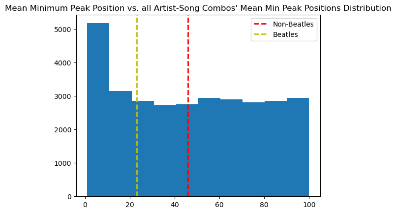

```python
min_performer_peak_pos_mean = int(min_performer_peak_pos_mean.iloc[0,0])
plt.axvline(min_performer_peak_pos_mean, color='r', linestyle='dashed', linewidth=2, label='Non-Beatles')
max_wks_peak_beat_mean = int(max_wks_peak_beat_mean.iloc[0,0])
plt.axvline(max_wks_peak_beat_mean, color='y', linestyle='dashed', linewidth=2, label='Beatles')
plt.title("Mean Minimum Peak Position vs. all Artist-Song Combos' Mean Min Peak Positions Distribution")
plt.legend()
plt.hist(data=min_performer_peak, x='peak_pos');
```

### Method 5 Part III: preserve the true wks_on_chart & peak_pos mean values in the raw data (includes one-hit wonder data)

### Mechanics 5 Part III: let's add a column that counts the times a performer/title were on the charts and add a columns to the df with those counts

```python
grouped_df = df2.groupby(['performer', 'title']).count()
# doing a free for all group by on all of the columns without using .agg will collapse the grouped by cols into rows instead of cols
# you'll have to do a reset_index if you do that like the line below
#grouped_df = grouped_df.reset_index()
grouped_df.head()
```

| performer | title | chart_week | current_week | last_week | peak_pos | wks_on_chart |
| --- | --- | --- | --- | --- | --- | --- |
| "Groove" Holmes | Misty | 11 | 11 | 10 | 11 | 11 |
|  | What Now My Love | 3 | 3 | 2 | 3 | 3 |
| "Little" Jimmy Dickens | May The Bird Of Paradise Fly Up Your Nose | 10 | 10 | 9 | 10 | 10 |
| "Pookie" Hudson | I Know I Know | 1 | 1 | 0 | 1 | 1 |
| "Weird Al" Yankovic | Amish Paradise | 16 | 16 | 15 | 16 | 16 |

```python
grouped_df = grouped_df.reset_index()
# this is the main command you have to do to pop the rows back into columns, but by that time, you've lost
#you're original values so this method really doesn't work in the end
```

```python
grouped_df['hit_count'] = grouped_df.groupby(['performer'], as_index=False)['performer'].transform('count')
grouped_df['perf_woc_max'] = grouped_df.groupby(['performer'], as_index=False)['wks_on_chart'].transform('max')
# grouped_df['perf_peak_min'] = grouped_df.groupby(['performer'], as_index=False)['song_peak_min'].transform('min')
#yes, it looks like this is going to work, just keep adding the columns back in from df2 (or df as well maybe - nah, probly not df since it is already cut down to only beatles by now)
```

```python
grouped_df2 = df2.groupby(['performer','title']).min()
# doing a free for all group by on all of the columns without using .agg will collapse the grouped by cols into rows instead of cols
# you'll have to do a reset_index if you do that like the line below
```

```python
grouped_df2 = grouped_df2.reset_index()
grouped_df2.head()
```

|  | performer | title | chart_week | current_week | last_week | peak_pos | wks_on_chart |
| --- | --- | --- | --- | --- | --- | --- | --- |
| 0 | "Groove" Holmes | Misty | 1966-06-25 | 44 | 44.0 | 44 | 1 |
| 1 | "Groove" Holmes | What Now My Love | 1966-10-01 | 96 | 98.0 | 96 | 1 |
| 2 | "Little" Jimmy Dickens | May The Bird Of Paradise Fly Up Your Nose | 1965-10-16 | 15 | 15.0 | 15 | 1 |
| 3 | "Pookie" Hudson | I Know I Know | 1963-05-25 | 96 | NaN | 96 | 1 |
| 4 | "Weird Al" Yankovic | Amish Paradise | 1996-03-30 | 53 | 53.0 | 53 | 1 |

```python
#i need a df that has alreadu been grouped down to perfomer/tite/e -- ;ole
# Merge df1 and df2 on both 'ID' and 'Name' columns

merged_df = pd.merge(grouped_df, grouped_df2, on=['performer', 'title'], how='inner') #df doesn't work here for some reason--

# Print the merged DataFrame
merged_df.head()

# That's it - take performer, title, wks_on_chart_x, hit_count, perf_woc_max from grouped_df and peak_pos_y (for song) from grouped_df2
# only stat I seem to be missing is the perf_peak_min
```

|  | performer | title | chart_week_x | current_week_x | last_week_x | peak_pos_x | wks_on_chart_x | hit_count | perf_woc_max | chart_week_y | current_week_y | last_week_y | peak_pos_y | wks_on_chart_y |
| --- | --- | --- | --- | --- | --- | --- | --- | --- | --- | --- | --- | --- | --- | --- |
| 0 | "Groove" Holmes | Misty | 11 | 11 | 10 | 11 | 11 | 2 | 11 | 1966-06-25 | 44 | 44.0 | 44 | 1 |
| 1 | "Groove" Holmes | What Now My Love | 3 | 3 | 2 | 3 | 3 | 2 | 11 | 1966-10-01 | 96 | 98.0 | 96 | 1 |
| 2 | "Little" Jimmy Dickens | May The Bird Of Paradise Fly Up Your Nose | 10 | 10 | 9 | 10 | 10 | 1 | 10 | 1965-10-16 | 15 | 15.0 | 15 | 1 |
| 3 | "Pookie" Hudson | I Know I Know | 1 | 1 | 0 | 1 | 1 | 1 | 1 | 1963-05-25 | 96 | NaN | 96 | 1 |
| 4 | "Weird Al" Yankovic | Amish Paradise | 16 | 16 | 15 | 16 | 16 | 11 | 20 | 1996-03-30 | 53 | 53.0 | 53 | 1 |

```python
## grouped_df[grouped_df[('hit_count')] > 1]
grouped_df_noOneHits = merged_df[merged_df[('hit_count')] > 1]
# yes this is what i want but do it on df2 instead to not lose the peak_pos & woc means when determining the hit_count col?
```

## Now come up with the min peaks for each performer and call perf_peak_min

```python
# grouped_df_noOneHits['woc_max0'] = df2.groupby(['performer'], as_index=False)['wks_on_chart'].transform('max')
grouped_df_noOneHits['perf_peak_min'] = grouped_df_noOneHits.groupby(['performer'], as_index=False)['peak_pos_y'].transform('min')
grouped_df_noOneHits.head()
# this gets new mean of non-one hit wonder song-artist combos
```

|  | performer | title | chart_week_x | current_week_x | last_week_x | peak_pos_x | wks_on_chart_x | hit_count | perf_woc_max | chart_week_y | current_week_y | last_week_y | peak_pos_y | wks_on_chart_y | perf_peak_min |
| --- | --- | --- | --- | --- | --- | --- | --- | --- | --- | --- | --- | --- | --- | --- | --- |
| 0 | "Groove" Holmes | Misty | 11 | 11 | 10 | 11 | 11 | 2 | 11 | 1966-06-25 | 44 | 44.0 | 44 | 1 | 44 |
| 1 | "Groove" Holmes | What Now My Love | 3 | 3 | 2 | 3 | 3 | 2 | 11 | 1966-10-01 | 96 | 98.0 | 96 | 1 | 44 |
| 4 | "Weird Al" Yankovic | Amish Paradise | 16 | 16 | 15 | 16 | 16 | 11 | 20 | 1996-03-30 | 53 | 53.0 | 53 | 1 | 9 |
| 5 | "Weird Al" Yankovic | Canadian Idiot | 3 | 3 | 2 | 3 | 3 | 11 | 20 | 2006-10-21 | 82 | 82.0 | 82 | 1 | 9 |
| 6 | "Weird Al" Yankovic | Eat It | 12 | 12 | 11 | 12 | 12 | 11 | 20 | 1984-03-10 | 12 | 12.0 | 12 | 1 | 9 |

### Method 5 Pt. III.5: Now use the new no one hit wonders means and peak positions to redo the comparison and chart above.

```python
# grouped_df_noOneHits['all_peak_mean'] = grouped_df_noOneHits['perf_peak_min'].mean() # <-- group by to get the mean of the perf_peak_min and mean of perf_woc_max
#remember code above to do a group by of one column by a certain agg f(x)
#taking the above line out and just taking mean of df before taking max of wks_on_hcart & peak_pos gives you weighted average that realtes the ore records the more weight the peak_pos has for that record
min_peak_no1 = grouped_df_noOneHits['perf_peak_min'].mean()
print ("Message 5 Part 3.5:")
print(min_peak_no1)
print("is the average performer's best rank / lowest peak position number value after 1-hit wonders removed")
max_woc_no1 = grouped_df_noOneHits['perf_woc_max'].mean()
print(max_woc_no1)
print("is the average performer's longest # of weeks on the charts for one song after 1-hit wonders removed")
```

```
Message 5 Part 3.5:
11.400943199365635
is the average performer's best rank / lowest peak position number value after 1-hit wonders removed
22.845916280622678
is the average performer's longest # of weeks on the charts for one song after 1-hit wonders removed
```

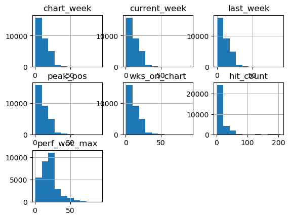

```python
grouped_df.hist();
```

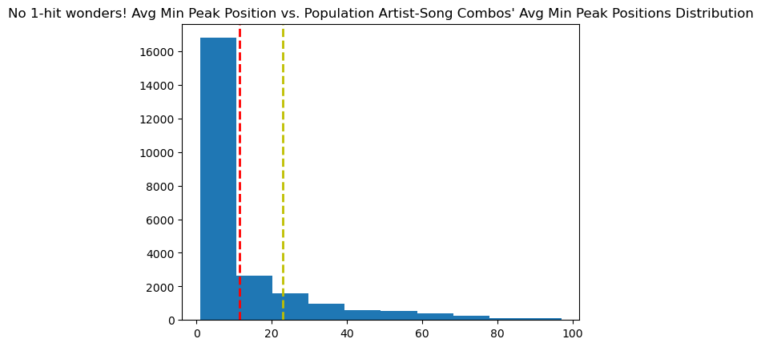

```python
max_wks_peak_beat_no1s = df.groupby(['performer', 'title'], as_index=False).agg({'wks_on_chart': 'max', 'peak_pos': 'min'})
#taking the above line out and just taking mean of df before taking max of wks_on_hcart & peak_pos gives you weighted average that realtes the ore records the more weight the peak_pos has for that record

max_wks_peak_beat_mean_no1s = max_wks_peak_beat_no1s.groupby(by='performer').agg(x=('peak_pos','mean'))
max_wks_peak_beat_mean_no1s

min_performer_peak_no1s = df2.groupby(['performer', 'title'], as_index=False).agg({'peak_pos': 'min'})
min_performer_peak_pos_mean_no1s = min_performer_peak_no1s.agg(x=('peak_pos','mean'))
min_performer_peak_no1s.agg(x=('peak_pos','mean'))

min_performer_peak_pos_mean_no1s = int(min_performer_peak_pos_mean_no1s.iloc[0,0])
plt.axvline(min_peak_no1, color='r', linestyle='dashed', linewidth=2, label='Beatles')
max_wks_peak_beat_mean_no1s = int(max_wks_peak_beat_mean_no1s.iloc[0,0])
plt.axvline(max_wks_peak_beat_mean_no1s, color='y', linestyle='dashed', linewidth=2, label='Non-Beatles')
plt.title("No 1-hit wonders! Avg Min Peak Position vs. Population Artist-Song Combos' Avg Min Peak Positions Distribution")
#plt.legend()
plt.hist(data=grouped_df_noOneHits, x='perf_peak_min');
#plt.show()
```

### Message 5 Pt 3.5: The Beatles average highest position rank was 23. They would not be resigned with this performer avg min peak pos after one-hit wonders were removed since industry avg performer min peak was 11 and 11 <= 23. Which means that most of 1-hit wonders weren't chart toppers since the mean went up for the population afterwards. Getting rid of the one-hit wonders makes overall career performer minimum peak position more higher ranked (less value / closer to 1.)

### Note: One-hit wonders are back in the following data...

### Method 5 Part IV: Let's deal only with data where only performers who had at least one song on the charts longer than twist and shout (26 wks)

### Mechanics 5 Part IV: create new df only with performers who had songs on charts longer than twist and shout. Now assign the mean for wks_on_chart and peak_pos to two new columns in the df, so can plot them. Hmmm, maybe I'll do a max & min respectively instead. Maybe don't worry about doing plot of those two vars and just go straight to mrm.

```python
import numpy as np
results = np.where((max3['wks_on_chart'] > bmaxweeks), (max3['performer'], max3['title'], max3['wks_on_chart']), np.nan)
df3 = pd.DataFrame(results).transpose()
df3=df3.rename(columns={0:"Performer",1:"Title", 2:"Wks_On_Chart"})
df3 = df3.dropna()
print (df3)
```

```
            Performer                      Title Wks_On_Chart
0       Glass Animals                 Heat Waves           91
1          The Weeknd            Blinding Lights           90
2     Imagine Dragons                Radioactive           87
3          AWOLNATION                       Sail           79
4            Dua Lipa                 Levitating           77
...               ...                        ...          ...
1255           Calboy                    Envy Me           27
1256          50 Cent             Just A Lil Bit           27
1257              US3  Cantaloop (Flip Fantasia)           27
1258      Gary Wright              Love Is Alive           27
1259             P!nk                 Most Girls           27

[1260 rows x 3 columns]
```

```python
print (len(df3.index))
```

```
1260
```

```python
print ("Message 5a: The Beatles longest run of weeks on the chart in America was for \r") # + max1.iloc[0].wks_on_chart
print (max1.iloc[0].wks_on_chart) #+ print ("\r weeks")
print ("weeks")
```

```
Message 5a: The Beatles longest run of weeks on the chart in America was for
26
weeks
```

```python
print ("Message 5b: There were ")
print (len(df3.index))
print ("other bands that had songs with longer runs than that.")
```

[output not shown]

```python
# let's save this to an image
plt.savefig("billboardHist1");
```